# Vignette Title

## log-log p-value

Firstly, we want to visualise the p-values for expression and methylation from negative binomial test and t-test respectively.

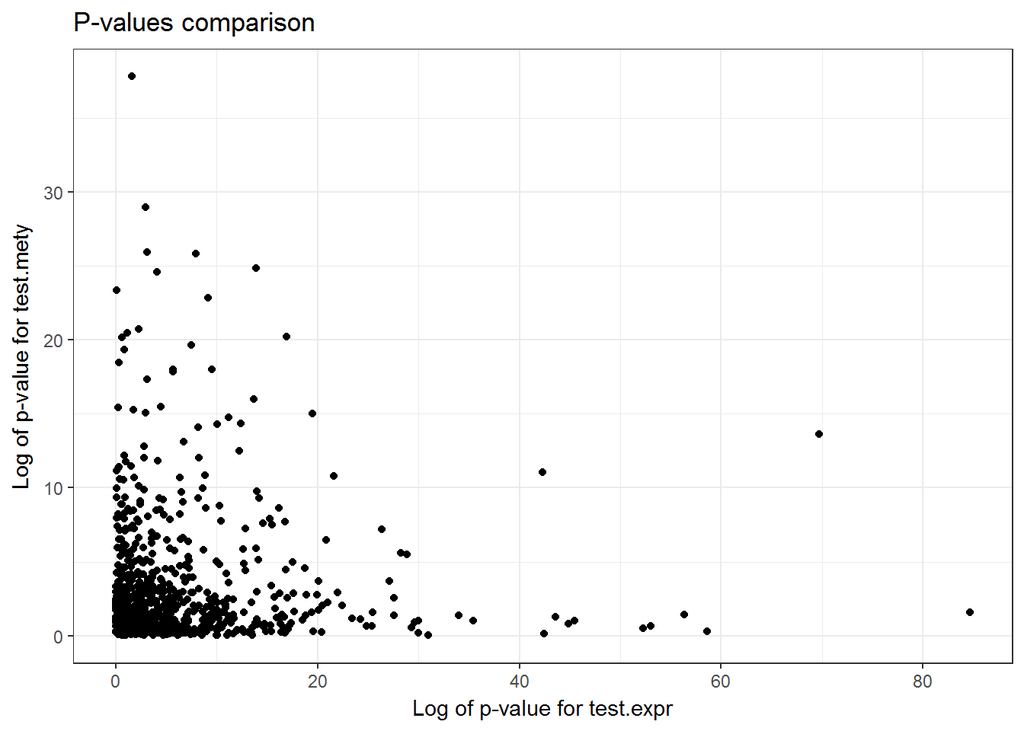

```r
p_values_plot(test.expr, test.mety)
```

Additionally, `names` parameter allows to mark genes with sum of p-values for methylation and expression, lower than given value. Value of parameter `names` defines, number of genes to label.

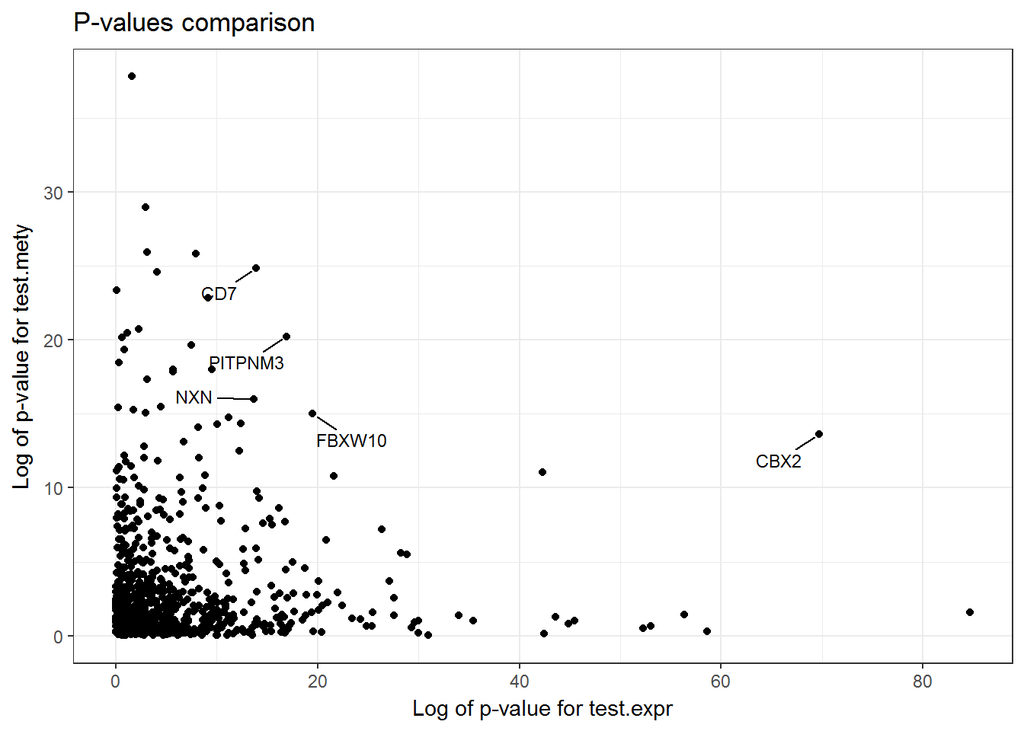

```r
p_values_plot(test.expr, test.mety, names = 5)
```

To read more about `p_values_plot` (e.g other ways to labeling genes) see help page for that function.

## Volcano plot

For identify changes in our data sets we use a volcano plot - some type of scatter-plot. It plots logarithm of p-value versus logarithm of fold-change on the y and x axes, respectively.

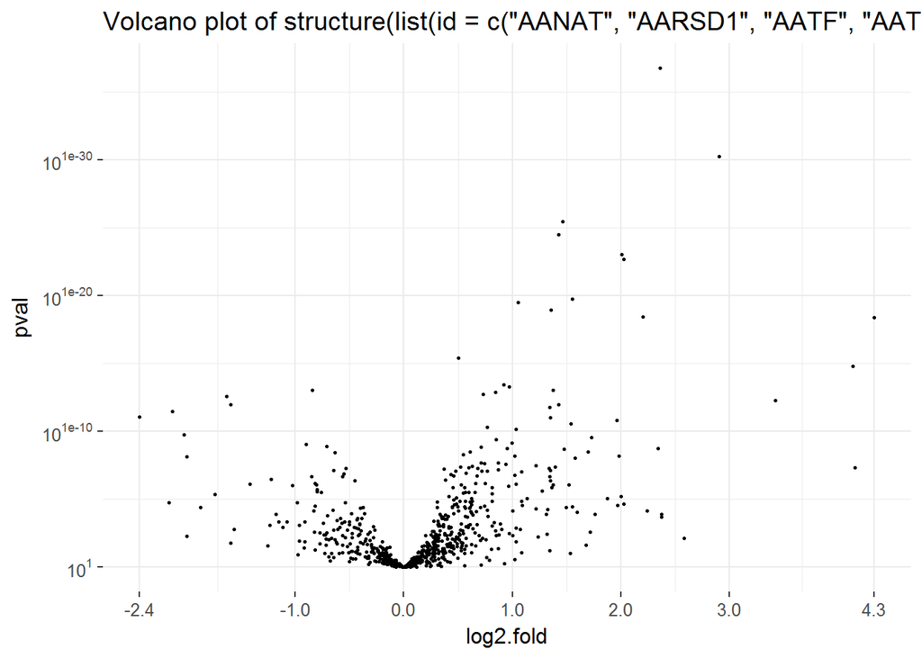

```r
volcano_plot(test.expr)
```

Function `volcano_plot` has parameters that allow to better analyze the results: `line` and `names`. The `line` parameter allows to set the horizontal line on plot on selected value. The `names` parameter signs choosen number of genes with the lowest p-value.

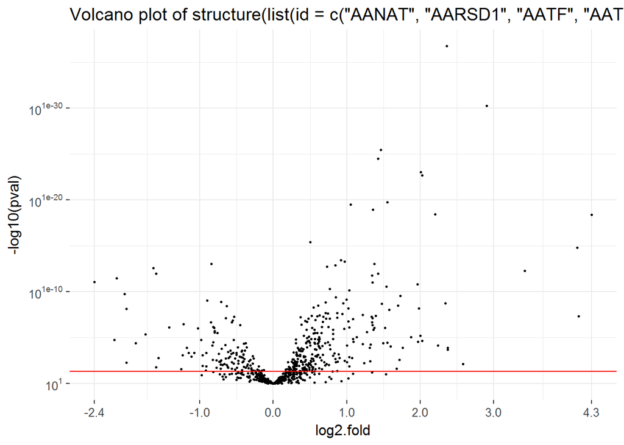

```r
volcano_plot(test.expr, line = 0.05)
```

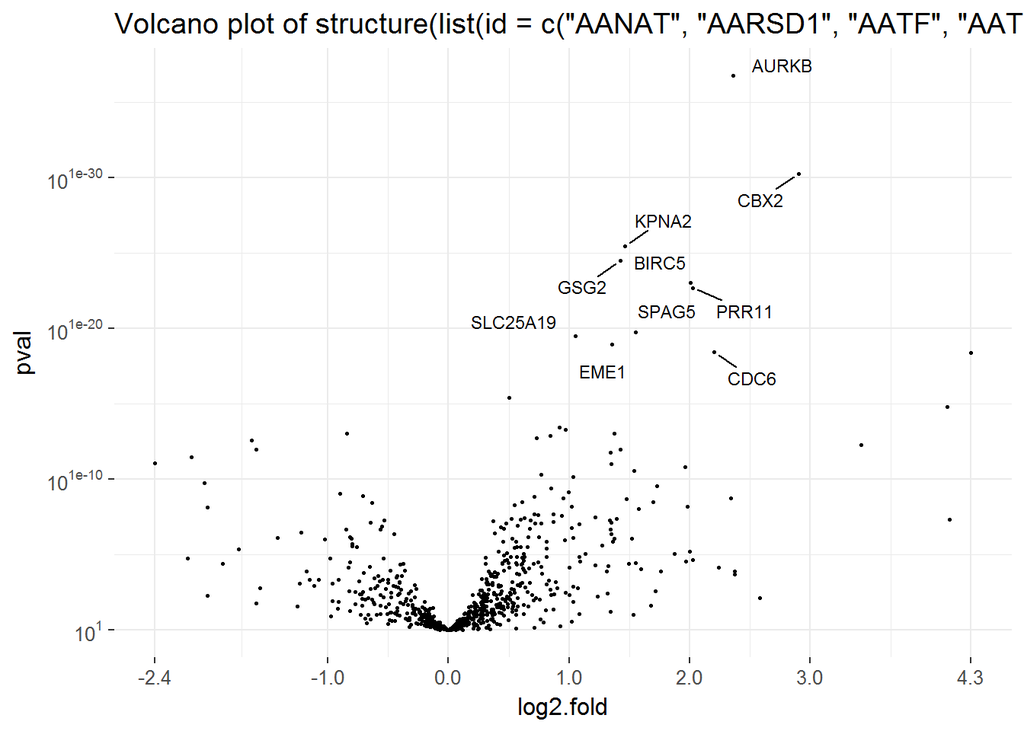

```r
volcano_plot(test.expr, names = 10)
```

## Methylation and expression for one gene.

In the end we want to present the distribution of methylation and expression for choosen genes.

Function `CpG_mean` computes methylation means of CpG islands for choosen gene. In this case: “BRCA1”

```r
BRCA1_gene <- CpG_mean(BRCA_methylation_chr17, "BRCA1")
BRCA1_gene
```

```
##             Name  MapInfo Symbol CPG_ISLAND CPG_ISLAND_LOCATIONS
## 4712  cg04658354 38530970  BRCA1       TRUE 17:38530194-38531162
## 6961  cg06973652 38532148  BRCA1       TRUE 17:38531525-38532730
## 7047  cg07054526 38526034  BRCA1       TRUE 17:38525979-38526990
## 8929  cg08993267 38530848  BRCA1       TRUE 17:38530194-38531162
## 11917 cg11964474 38532181  BRCA1       TRUE 17:38531525-38532730
## 19075 cg19088651 38530739  BRCA1       TRUE 17:38530194-38531162
## 19527 cg19531713 38530585  BRCA1       TRUE 17:38530194-38531162
##             mean
## 4712  0.05802403
## 6961  0.83772148
## 7047  0.93138624
## 8929  0.06280625
## 11917 0.79200965
## 19075 0.11090400
## 19527 0.10361921
```

### Methylation and expression in groups.

Two subtype groups of cancer in one plot.

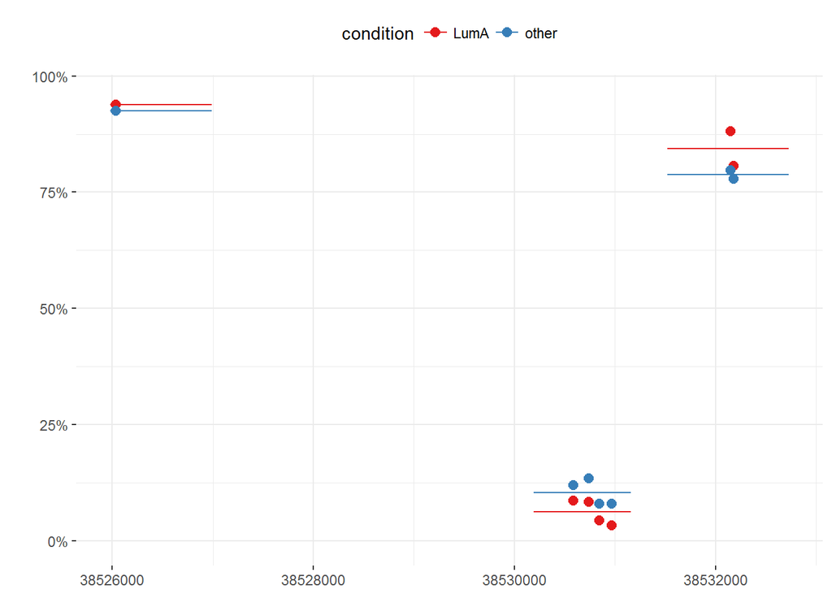

```r
condition <- ifelse(BRCA_methylation_chr17$SUBTYPE=="LumA","LumA", "other")
genereg_vs_met(BRCA_methylation_chr17, condition, "BRCA1")
```

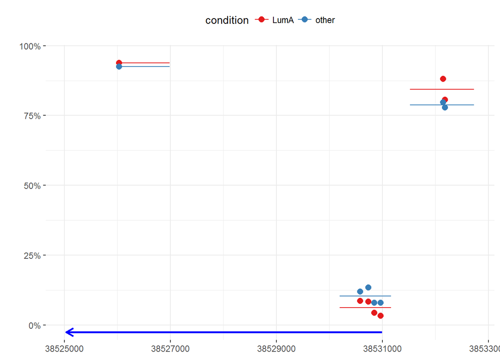

```r
genereg_vs_met(BRCA_methylation_chr17, condition, "BRCA1", show_gen=TRUE)
```

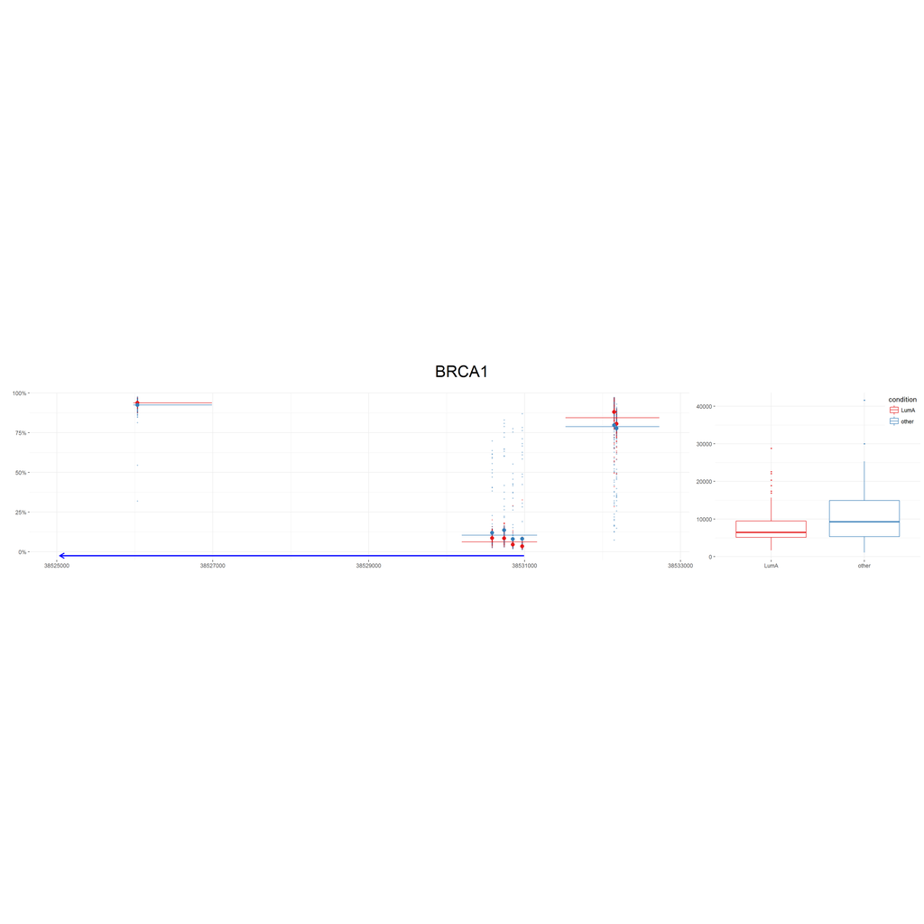

```r
visual_gene(condition.e, condition.m, BRCA_methylation_chr17[,-1],BRCA_mRNAseq_chr17[,-1], "BRCA1", test.expr, test.mety)
```

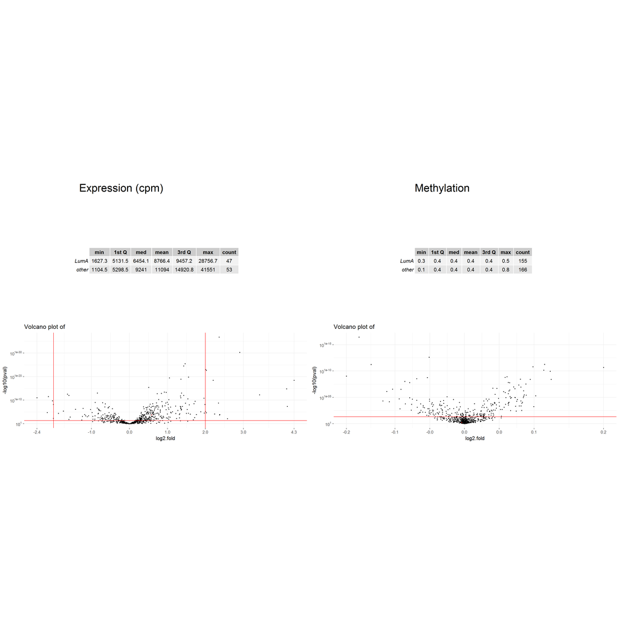

```r
visual_volc(condition.e, condition.m, BRCA_methylation_chr17[,-1],BRCA_mRNAseq_chr17[,-1], "BRCA1", list(test.expr), list(test.mety))
```

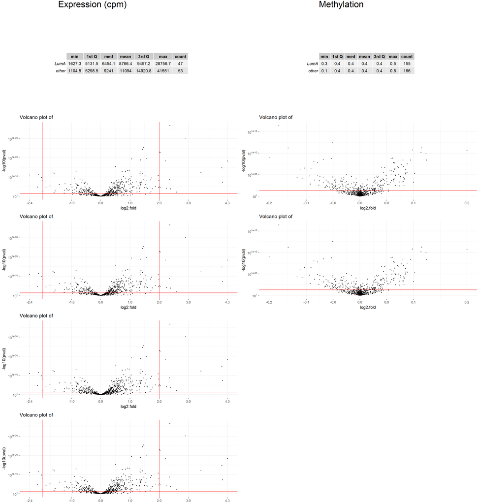

```r
visual_volc(condition.e, condition.m, BRCA_methylation_chr17[,-1],BRCA_mRNAseq_chr17[,-1], "BRCA1", list(test.expr,test.expr,test.expr,test.expr), list(test.mety,test.mety))
```